# Microdialysis 2020 data analysis

Andreas Schneider

21/09/2020

```r
suppressMessages({
  library(here)
  library(vegan)
  library(RColorBrewer)
  library(ggplot2)
  library(gridExtra)
  library(phyloseq)
  library(reshape2)
  library(zinbwave)
  library(pheatmap)
  library(DESeq2)
  library(tidyverse)
  library(lefser)
  library(grid)
  library(agricolae)
})

source(here("src/UPSCb-common/src/R/featureSelection.R"))
source(here("src/UPSCb-common/Rtoolbox/src/utilsDE.r"))
```

# Import data

We start with importing the preprocessed data and filtering out very low abundant taxa.

```r
taxa <- readRDS(here("results/taxa.rds"))
seqtab.sw4 <- readRDS(here("results/seqtab_final.rds"))
meta <- readRDS(here("results/meta.rds"))
read_stats <- as.data.frame(readRDS(here("results/read_stats.rds")))
```

# Read numbers

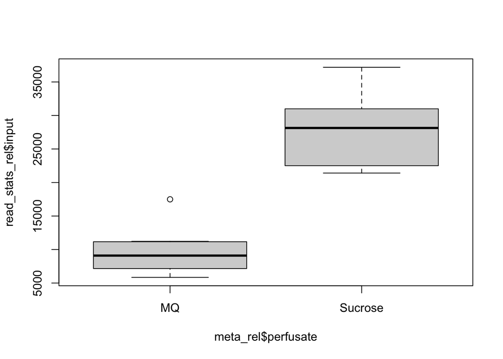

```r
meta$Litter <- ifelse(grepl("Yes", meta$Litter), "Litter", "No_Litter")
meta$condition <- paste0(meta$perfusate, ".", meta$Litter)

meta_rel <- meta[c(1:17),]
read_stats_rel <- read_stats[c(1:17),]

#Input first
boxplot(read_stats_rel$input~meta_rel$perfusate)
```

```r
#Looks very significant!
shapiro.test(read_stats_rel$input[meta_rel$perfusate=="MQ"])
```

```
##
##  Shapiro-Wilk normality test
##
## data:  read_stats_rel$input[meta_rel$perfusate == "MQ"]
## W = 0.85548, p-value = 0.1082
```

```r
shapiro.test(read_stats_rel$input[meta_rel$perfusate=="Sucrose"])
```

```
##
##  Shapiro-Wilk normality test
##
## data:  read_stats_rel$input[meta_rel$perfusate == "Sucrose"]
## W = 0.92436, p-value = 0.4296
```

```r
t.test(read_stats_rel$input~meta_rel$perfusate)
```

```
##
##  Welch Two Sample t-test
##
## data:  read_stats_rel$input by meta_rel$perfusate
## t = -8.2803, df = 14.496, p-value = 7.162e-07
## alternative hypothesis: true difference in means between group MQ and group Sucrose is not equal to 0
## 95 percent confidence interval:
##  -22694.62 -13380.30
## sample estimates:
##      mean in group MQ mean in group Sucrose
##              9773.875             27811.333
```

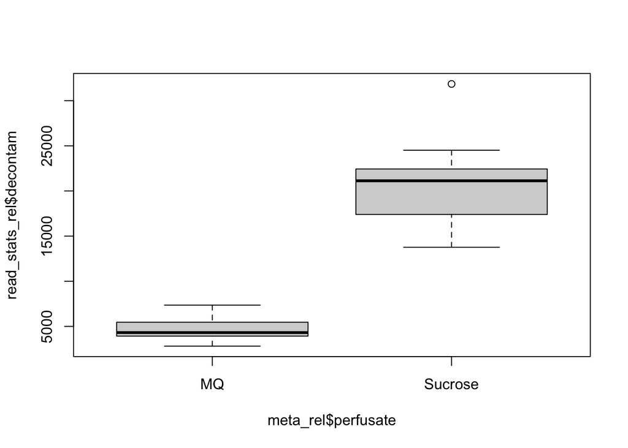

```r
#Final read numbers
boxplot(read_stats_rel$decontam~meta_rel$perfusate)
```

```r
#Looks very significant!
shapiro.test(read_stats_rel$decontam[meta_rel$perfusate=="MQ"])
```

```
##
##  Shapiro-Wilk normality test
##
## data:  read_stats_rel$decontam[meta_rel$perfusate == "MQ"]
## W = 0.94312, p-value = 0.642
```

```r
shapiro.test(read_stats_rel$decontam[meta_rel$perfusate=="Sucrose"])
```

```
##
##  Shapiro-Wilk normality test
##
## data:  read_stats_rel$decontam[meta_rel$perfusate == "Sucrose"]
## W = 0.94365, p-value = 0.6208
```

```r
t.test(read_stats_rel$decontam~meta_rel$perfusate)
```

```
##
##  Welch Two Sample t-test
##
## data:  read_stats_rel$decontam by meta_rel$perfusate
## t = -8.8845, df = 9.2177, p-value = 8.09e-06
## alternative hypothesis: true difference in means between group MQ and group Sucrose is not equal to 0
## 95 percent confidence interval:
##  -20509.12 -12208.49
## sample estimates:
##      mean in group MQ mean in group Sucrose
##               4696.75              21055.56
```

```r
sd(read_stats_rel$decontam[meta_rel$perfusate=="MQ"])
```

```
## [1] 1392.937
```

```r
sd(read_stats_rel$decontam[meta_rel$perfusate=="Sucrose"])
```

```
## [1] 5322.594
```

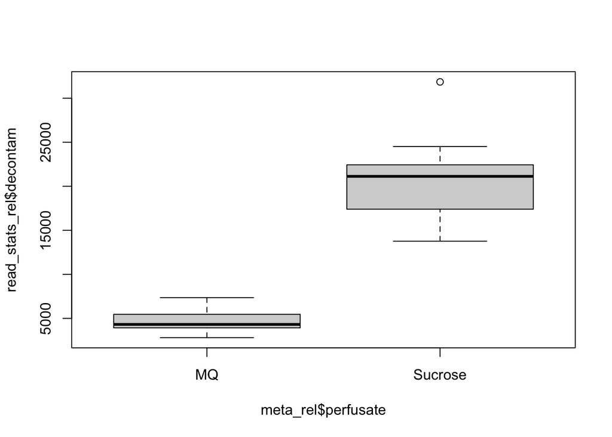

```r
#Clean version for manuscript
boxplot(read_stats_rel$decontam~meta_rel$perfusate)
```

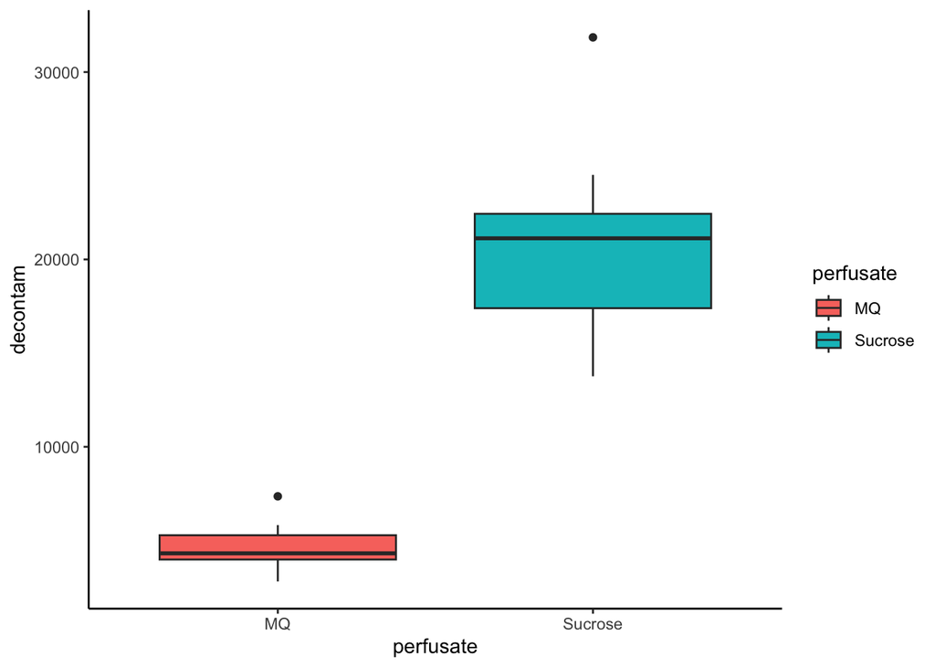

```r
read_stats_plot <- data.frame(decontam=read_stats_rel[,8], meta_rel)

(box1 <- ggplot(read_stats_plot, aes(x = perfusate, y = decontam))+
  geom_boxplot(aes(fill=perfusate))+
  theme_classic())
```

```r
dir.create(file.path(here("results/figures")), showWarnings = FALSE)
# ggsave("FigureS1.pdf",
#        box1,
#        device = "pdf",
#        path = "results/figures",
#        width = 100,
#        height = 70,
#        units = "mm")
```

Sucrose consistently (and significantly) yielded higher number of fungal reads!

Litter sucrose vs no sucrose (and water vs no water) comparison:

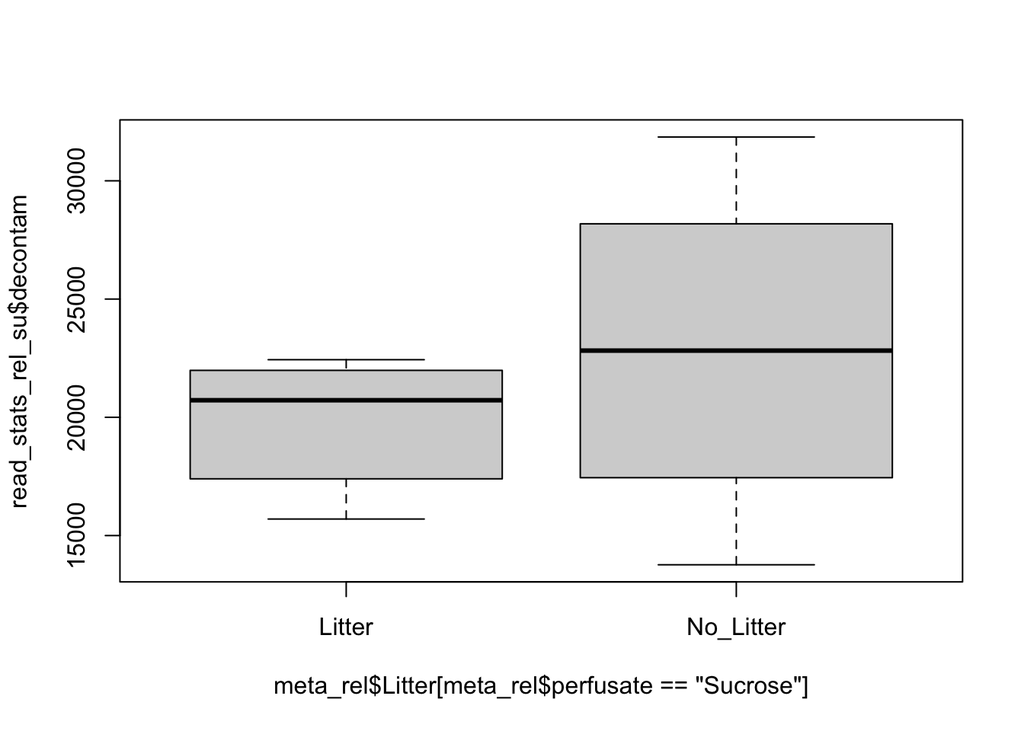

```r
read_stats_rel_su <- read_stats_rel[meta_rel$perfusate=="Sucrose",]
read_stats_rel_mq <- read_stats_rel[meta_rel$perfusate=="MQ",]

boxplot(read_stats_rel_su$decontam~meta_rel$Litter[meta_rel$perfusate=="Sucrose"])
```

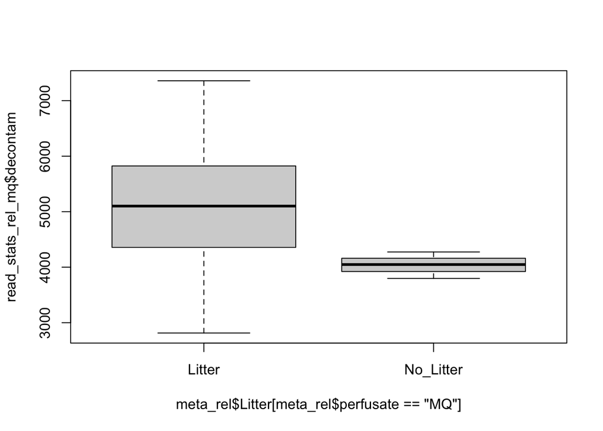

```r
boxplot(read_stats_rel_mq$decontam~meta_rel$Litter[meta_rel$perfusate=="MQ"])
```

```r
t.test(read_stats_rel_su$decontam~meta_rel$Litter[meta_rel$perfusate=="Sucrose"])
```

```
##
##  Welch Two Sample t-test
##
## data:  read_stats_rel_su$decontam by meta_rel$Litter[meta_rel$perfusate == "Sucrose"]
## t = -0.79508, df = 3.7479, p-value = 0.4739
## alternative hypothesis: true difference in means between group Litter and group No_Litter is not equal to 0
## 95 percent confidence interval:
##  -14523.807   8190.707
## sample estimates:
##    mean in group Litter mean in group No_Litter
##                19648.20                22814.75
```

```r
t.test(read_stats_rel_mq$decontam~meta_rel$Litter[meta_rel$perfusate=="MQ"])
```

```
##
##  Welch Two Sample t-test
##
## data:  read_stats_rel_mq$decontam by meta_rel$Litter[meta_rel$perfusate == "MQ"]
## t = 1.3702, df = 4.2614, p-value = 0.2384
## alternative hypothesis: true difference in means between group Litter and group No_Litter is not equal to 0
## 95 percent confidence interval:
##  -1028.481  3131.147
## sample estimates:
##    mean in group Litter mean in group No_Litter
##                5091.000                4039.667
```

# Filtering of low abundance taxa

```r
ccc <- as.factor(meta_rel$perfusate)
names(ccc) <- meta_rel$SciLifeID
seqtab.sw5 <- seqtab.sw4[featureSelect(data.matrix(seqtab.sw4), ccc, 3, 2),]
seqtab.sw5 <- seqtab.sw5[featureSelectProp(data.matrix(seqtab.sw5), ccc, 0.00005),]
```

# Number of OTUs

```r
seqtab.sw5_MQ <- seqtab.sw5[,meta_rel$perfusate=="MQ"]
seqtab.sw5_MQ <- seqtab.sw5_MQ[rowSums(seqtab.sw5_MQ)>sum(seqtab.sw5_MQ)*0.00003,]

seqtab.sw5_su <- seqtab.sw5[,meta_rel$perfusate=="Sucrose"]
seqtab.sw5_su <- seqtab.sw5_su[rowSums(seqtab.sw5_su)>sum(seqtab.sw5_su)*0.00003,]

length(intersect(rownames(seqtab.sw5_MQ), rownames(seqtab.sw5_su)))
```

```
## [1] 181
```

```r
length(setdiff(rownames(seqtab.sw5_MQ), rownames(seqtab.sw5_su)))
```

```
## [1] 20
```

```r
length(setdiff(rownames(seqtab.sw5_su), rownames(seqtab.sw5_MQ)))
```

```
## [1] 5
```

```r
common_OTUs <- intersect(rownames(seqtab.sw5_MQ), rownames(seqtab.sw5_su))
taxa_common <- taxa[common_OTUs,]
taxa_common2 <- taxa_common
taxa_common2 <- taxa_common2[,c(5:10,1)]

#write.csv(taxa_common2, here("results/analysis/common_OTUs.csv"), row.names = TRUE, quote = FALSE)
```

Out of the 206 total filtered OTUs, 181 are in common between the treatments, 20 unique to the MQ samples, and 5 unique to the Sucrose samples.

Here comes a list of the OTUs that are exclusive to the two treatments, with their average relative abundance, and the number of samples they appear in in both treatments:

```r
mq_ex <- setdiff(rownames(seqtab.sw5_MQ), rownames(seqtab.sw5_su))

seqtab.sw5_MQ_p <- prop.table(data.matrix(seqtab.sw5_MQ), margin = 2)*100
seqtab.sw5_MQ_p_ex <- seqtab.sw5_MQ_p[mq_ex,]

mq_ex_tab <- cbind(Mean=rowMeans(seqtab.sw5_MQ_p_ex),
                   Presence=rowSums(seqtab.sw5_MQ_p_ex>0),
                   taxa[mq_ex,c(5:10)])

mq_su <- setdiff(rownames(seqtab.sw5_su), rownames(seqtab.sw5_MQ))

seqtab.sw5_su_p <- prop.table(data.matrix(seqtab.sw5_su), margin = 2)*100
seqtab.sw5_su_p_ex <- seqtab.sw5_su_p[mq_su,]

su_ex_tab <- cbind(Mean=rowMeans(seqtab.sw5_su_p_ex),
                   Presence=rowSums(seqtab.sw5_su_p_ex>0),
                   taxa[mq_su,c(5:10)])

mq_ex_tab
```

```
##               Mean Presence             Phylum                      Class
## SOTU118 0.17685802        5 Unclassified.Fungi         Unclassified.Fungi
## SOTU166 0.07984520        6      Basidiomycota             Agaricomycetes
## SOTU170 0.08367499        6    Chytridiomycota         Rhizophydiomycetes
## SOTU173 0.06734814        6         Ascomycota            Dothideomycetes
## SOTU189 0.04730528        4      Basidiomycota             Agaricomycetes
## SOTU197 0.05496219        6      Basidiomycota            Tremellomycetes
## SOTU199 0.05218274        6      Basidiomycota       Geminibasidiomycetes
## SOTU202 0.05125495        4         Ascomycota              Leotiomycetes
## SOTU205 0.05686435        5      Basidiomycota             Agaricomycetes
## SOTU214 0.03508470        4      Basidiomycota             Agaricomycetes
## SOTU219 0.03086178        2         Ascomycota            Sordariomycetes
## SOTU221 0.03429903        4         Ascomycota             Orbiliomycetes
## SOTU222 0.03302249        3      Basidiomycota            Tremellomycetes
## SOTU224 0.04086259        3         Ascomycota    Unclassified.Ascomycota
## SOTU235 0.03340587        3         Ascomycota    Unclassified.Ascomycota
## SOTU237 0.02612879        3         Ascomycota            Arthoniomycetes
## SOTU238 0.02726769        4      Rozellomycota Unclassified.Rozellomycota
## SOTU248 0.02671560        2      Basidiomycota            Tremellomycetes
## SOTU256 0.02221463        2         Ascomycota              Leotiomycetes
## SOTU261 0.02480297        2         Ascomycota              Leotiomycetes
##                                Order                       Family
## SOTU118           Unclassified.Fungi           Unclassified.Fungi
## SOTU166                   Atheliales              Pilodermataceae
## SOTU170               Rhizophydiales  Unclassified.Rhizophydiales
## SOTU173                 Pleosporales              Melanommataceae
## SOTU189                   Agaricales               Cortinariaceae
## SOTU197                  Tremellales              Cryptococcaceae
## SOTU199             Geminibasidiales            Geminibasidiaceae
## SOTU202                   Helotiales                  Helotiaceae
## SOTU205                   Agaricales               Cortinariaceae
## SOTU214                   Agaricales               Cortinariaceae
## SOTU219               Coniochaetales              Coniochaetaceae
## SOTU221                   Orbiliales      Unclassified.Orbiliales
## SOTU222 Unclassified.Tremellomycetes Unclassified.Tremellomycetes
## SOTU224      Unclassified.Ascomycota      Unclassified.Ascomycota
## SOTU235      Unclassified.Ascomycota      Unclassified.Ascomycota
## SOTU237 Unclassified.Arthoniomycetes Unclassified.Arthoniomycetes
## SOTU238   Unclassified.Rozellomycota   Unclassified.Rozellomycota
## SOTU248                  Tremellales           Bulleribasidiaceae
```

[output cut: 8 more lines]

```
## SOTU197               Cryptococcus_2  Unclassified.Cryptococcus_2
## SOTU199               Geminibasidium  Unclassified.Geminibasidium
## SOTU202                   Crocicreas      Unclassified.Crocicreas
## SOTU205                  Cortinarius         Cortinarius_mucosus
## SOTU214  Unclassified.Cortinariaceae  Unclassified.Cortinariaceae
## SOTU219 Unclassified.Coniochaetaceae Unclassified.Coniochaetaceae
## SOTU221      Unclassified.Orbiliales      Unclassified.Orbiliales
## SOTU222 Unclassified.Tremellomycetes Unclassified.Tremellomycetes
## SOTU224      Unclassified.Ascomycota      Unclassified.Ascomycota
## SOTU235      Unclassified.Ascomycota      Unclassified.Ascomycota
## SOTU237 Unclassified.Arthoniomycetes Unclassified.Arthoniomycetes
## SOTU238   Unclassified.Rozellomycota   Unclassified.Rozellomycota
## SOTU248                Vishniacozyma     Vishniacozyma_victoriae
## SOTU256                     Blumeria           Blumeria_graminis
## SOTU261      Unclassified.Helotiales      Unclassified.Helotiales
```

```r
su_ex_tab
```

```
##                Mean Presence             Phylum              Class
## SOTU92  0.051313941        6         Ascomycota     Eurotiomycetes
## SOTU105 0.046614396        7      Basidiomycota    Tremellomycetes
## SOTU133 0.034686372        4  Mortierellomycota Mortierellomycetes
## SOTU223 0.008239083        6      Basidiomycota Microbotryomycetes
## SOTU273 0.003386499        2 Unclassified.Fungi Unclassified.Fungi
##                                   Order                          Family
## SOTU92                       Eurotiales                  Aspergillaceae
## SOTU105                  Filobasidiales                 Piskurozymaceae
## SOTU133                  Mortierellales                 Mortierellaceae
## SOTU223 Unclassified.Microbotryomycetes Unclassified.Microbotryomycetes
## SOTU273              Unclassified.Fungi              Unclassified.Fungi
##                                   Genus                         Species
## SOTU92                      Penicillium        Unclassified.Penicillium
## SOTU105                     Piskurozyma            Piskurozyma_arborea
## SOTU133                     Mortierella        Unclassified.Mortierella
## SOTU223 Unclassified.Microbotryomycetes Unclassified.Microbotryomycetes
## SOTU273              Unclassified.Fungi              Unclassified.Fungi
```

```r
ex_tab_all <- cbind(treatment_spec=c(rep("MQ Only", 20), rep("Sucrose Only", 5)), rbind(mq_ex_tab, su_ex_tab))
ex_tab_all2 <- ex_tab_all
ex_tab_all2$OTU_no <- rownames(ex_tab_all2)
ex_tab_all2 <- ex_tab_all2[,c(1, 4:9, 3, 10, 2)]
#write.csv(ex_tab_all2, here("results/analysis/uniq_OTUs.csv"), row.names = TRUE, quote = FALSE)
```

## Rarefaction curve

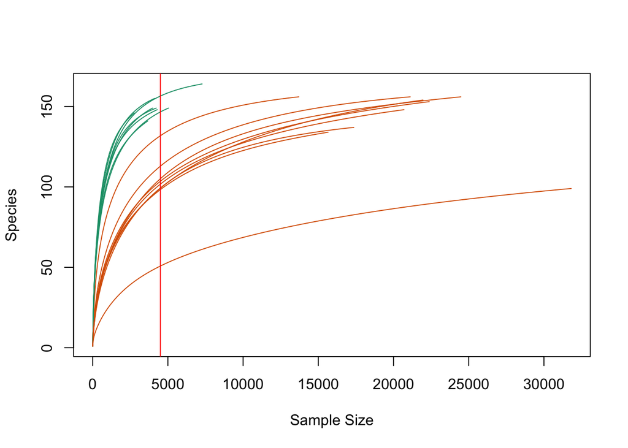

```r
rarecurve(t(seqtab.sw5), step = 50, label = FALSE, col = brewer.pal(3, "Dark2")[as.numeric(as.factor(meta_rel$perfusate))])
abline(v = 4500, col = "red")
```

What we can see here is that while the total richness is very similar in both treatments the MQ samples (dark green) have higher evenness and thus a steeper slope, while the full richness is only reached at high read numbers in the sucrose samples.

For later steps we can rarefy at 4500 reads.

## Richness

```r
set.seed(500)
seqtab.sw5_MQ_r <- t(rrarefy(t(seqtab.sw5_MQ), 4500))
```

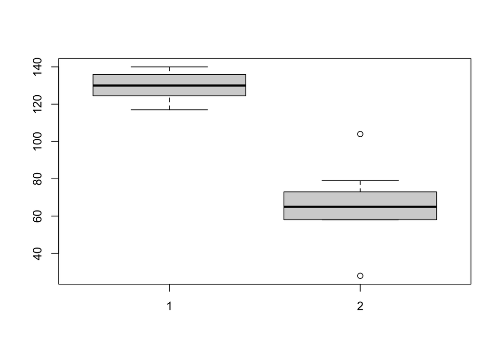

```r
seqtab.sw5_su_r <- t(rrarefy(t(seqtab.sw5_su), 4500))

rich_MQ <- colSums(seqtab.sw5_MQ_r>1)
rich_su <- colSums(seqtab.sw5_su_r>1)

boxplot(rich_MQ, rich_su)
```

```r
shapiro.test(rich_MQ)
```

```
##
##  Shapiro-Wilk normality test
##
## data:  rich_MQ
## W = 0.96906, p-value = 0.8906
```

```r
shapiro.test(rich_su)
```

```
##
##  Shapiro-Wilk normality test
##
## data:  rich_su
## W = 0.92889, p-value = 0.4709
```

```r
wilcox.test(rich_MQ, rich_su, exact = FALSE)
```

```
##
##  Wilcoxon rank sum test with continuity correction
##
## data:  rich_MQ and rich_su
## W = 72, p-value = 0.0006258
## alternative hypothesis: true location shift is not equal to 0
```

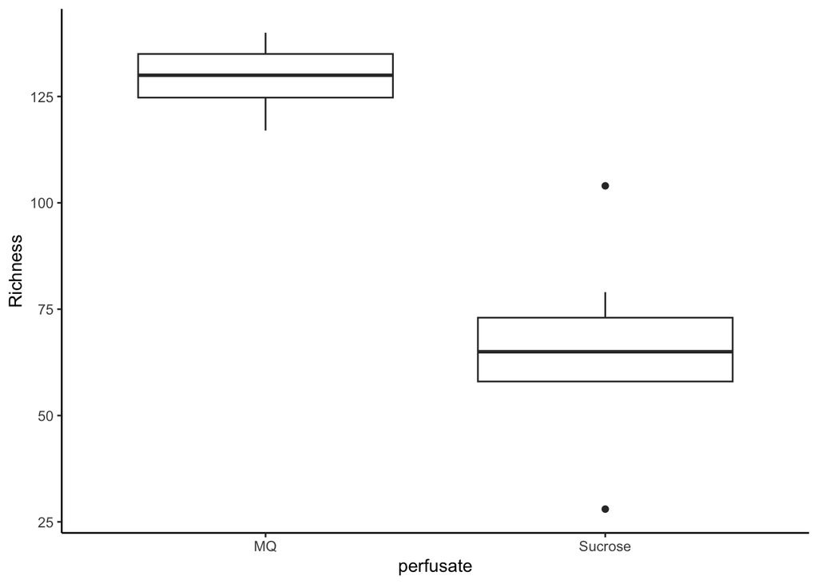

```r
#Same in ggplot
rich1 <- data.frame(SciLifeID=c(colnames(seqtab.sw5_MQ_r), colnames(seqtab.sw5_su_r)), Richness = c(rich_MQ, rich_su))

rich2 <- merge.data.frame(rich1, meta, by = "SciLifeID")

ggplot(rich2, aes(x = perfusate, y = Richness))+
  geom_boxplot()+
  theme_classic()
```

```r
# ggsave("FigureS1C.pdf",
#        device = "pdf",
#        path = "results/figures",
#        width = 59,
#        height = 70,
#        units = "mm")
```

The water probes show higher richness after rarefaction of counts to 4500 (to account for the differing number of reads), as expected from the rarefaction curves.

# Data analysis

## Alpha Diversity

The first analysis is basic alpha diversity, assessed by Shannon and Simpson diversity index values. For this we use the unrarefied raw counts.

```r
meta <- meta[colnames(seqtab.sw5),]



divs <- as.data.frame(cbind(Shannon=diversity(t(seqtab.sw5)), Simpson=diversity(t(seqtab.sw5), index = "simpson")))
divs$perfusate <- meta$perfusate
divs$litter <- as.factor(meta$Litter)
divs$condition <- as.factor(meta$condition)


shan <- ggplot(divs, aes(x = perfusate, y = Shannon, shape = litter))+
  geom_point()+
  ggtitle("Shannon Index")+
  coord_cartesian(ylim = c(0,5))+
  theme_minimal()+
  theme(axis.title.x = element_blank(),
        axis.text.x = element_text(angle = 45, vjust = 0.7))

# simp <- ggplot(divs, aes(x = perfusate, y = Simpson, shape = litter))+
#   geom_point()+
#   ggtitle("Simpson Index")+
#   coord_cartesian(ylim = c(0,1))+
#   theme_minimal()+
#   theme(axis.title.x = element_blank(),
#         axis.text.x = element_text(angle = 45, vjust = 0.7))
#
# grid.arrange(shan, simp, ncol = 2)
min(colSums(seqtab.sw5))
```

```
## [1] 2772
```

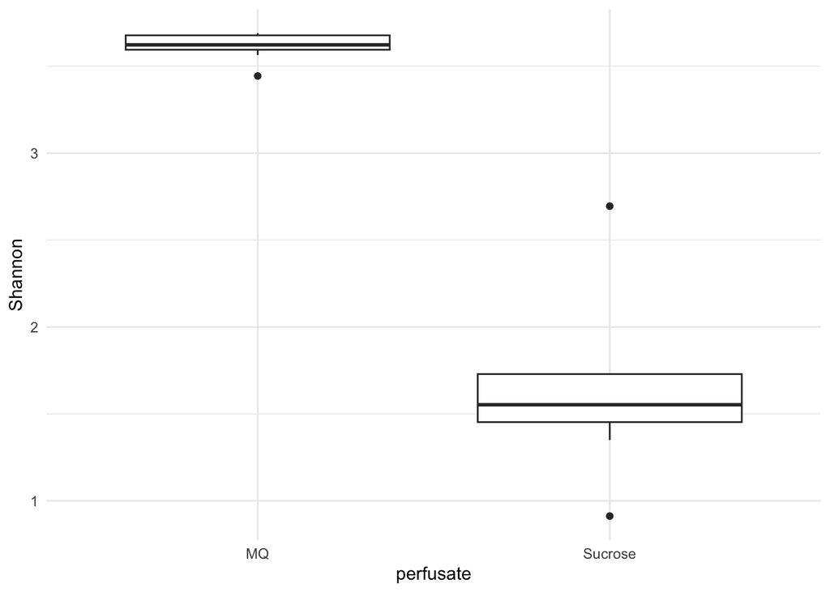

```r
(shan2 <- ggplot(divs, aes(x = perfusate, y = Shannon))+
  geom_boxplot()+
  theme_minimal())
```

```r
# ggsave("FigureS1A.pdf",
#        shan2,
#        device = "pdf",
#        path = "results/figures",
#        width = 59,
#        height = 70,
#        units = "mm")

wilcox.test(Shannon~perfusate, data = divs)
```

```
##
##  Wilcoxon rank sum exact test
##
## data:  Shannon by perfusate
## W = 72, p-value = 8.227e-05
## alternative hypothesis: true location shift is not equal to 0
```

```r
div_krus <- with(divs, kruskal(Shannon, condition, console = TRUE))
```

```
##
## Study: Shannon ~ condition
## Kruskal-Wallis test's
## Ties or no Ties
##
## Critical Value: 12.14837
## Degrees of freedom: 3
## Pvalue Chisq  : 0.006891823
##
## condition,  means of the ranks
##
##                    Shannon r
## MQ.Litter         14.00000 5
## MQ.No_Litter      12.66667 3
## Sucrose.Litter     4.80000 5
## Sucrose.No_Litter  5.25000 4
##
## Post Hoc Analysis
##
## t-Student: 2.160369
## Alpha    : 0.05
## Groups according to probability of treatment differences and alpha level.
##
## Treatments with the same letter are not significantly different.
##
##                    Shannon groups
## MQ.Litter         14.00000      a
## MQ.No_Litter      12.66667      a
## Sucrose.No_Litter  5.25000      b
## Sucrose.Litter     4.80000      b
```

```r
mean(divs$Shannon[divs$perfusate=="MQ"])
```

```
## [1] 3.613698
```

```r
sd(divs$Shannon[divs$perfusate=="MQ"])
```

```
## [1] 0.08155058
```

```r
mean(divs$Shannon[divs$perfusate=="Sucrose"])
```

```
## [1] 1.620825
```

```r
sd(divs$Shannon[divs$perfusate=="Sucrose"])
```

```
## [1] 0.4750513
```

The diversity index values are signifcantly higher in the MQ samples. Most likely the sucrose probes have a lower evenness due to some species dominating the community after having a competitive advantage over others. The litter does not seem to have an influence on alpha diversity.

## Beta diversity

In order to look at the beta diversity, we have to normalise the data in some way. I will again rarefy (to 4500), and this set of counts will be used for the remaining analyses.

```r
set.seed(500)
counts_rar <- t(rrarefy(t(seqtab.sw5), 4500))
```

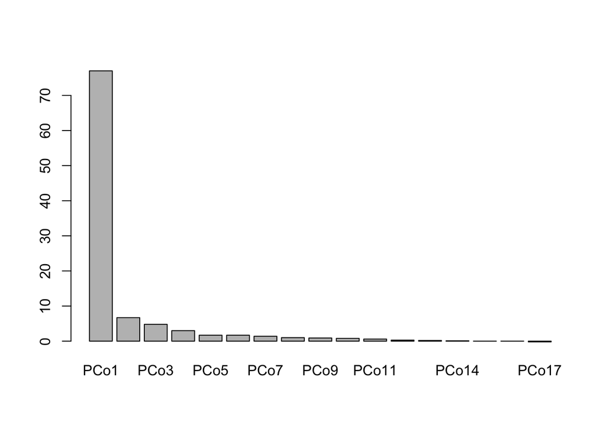

```r
taxa_ps <- as.matrix(taxa[rownames(seqtab.sw5),])

ps_rar <- phyloseq(otu_table(seqtab.sw5, taxa_are_rows = TRUE),
                   sample_data(meta),
                   tax_table(taxa_ps))
r.ord <- ordinate(ps_rar, "MDS", "bray")

#Scree Plot
percentages <- data.frame(PCo=paste0("PCo", seq(1, length(r.ord$values$Relative_eig), 1)),
                          percent=round(r.ord$values$Relative_eig*100, digits = 1))
barplot(percentages$percent, names.arg = percentages$PCo)
```

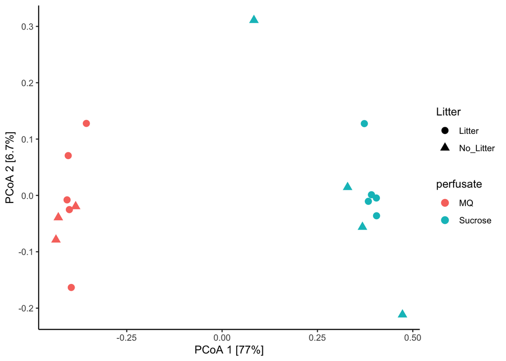

```r
(ordplot1 <- plot_ordination(ps_rar, r.ord, type = "samples", color = "perfusate", shape = "Litter")+
  geom_point(size = 3)+
  xlab(paste0("PCoA 1 [", round(r.ord$values$Relative_eig[1]*100, digits = 1), "%]"))+
  ylab(paste0("PCoA 2 [", round(r.ord$values$Relative_eig[2]*100, digits = 1), "%]"))+
  theme(legend.position = "none")+
  theme_classic()
)
```

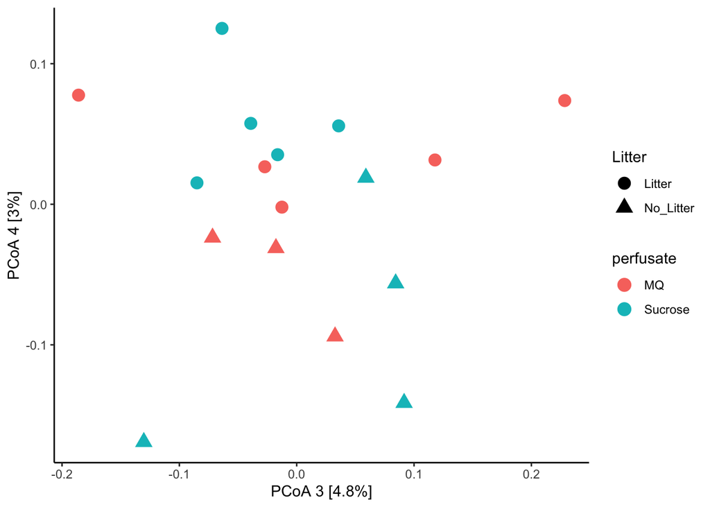

```r
(ordplot2 <- plot_ordination(ps_rar, r.ord, type = "samples", color = "perfusate", shape = "Litter", axes = 3:4)+
  geom_point(size = 4)+
  xlab(paste0("PCoA 3 [", round(r.ord$values$Relative_eig[3]*100, digits = 1), "%]"))+
  ylab(paste0("PCoA 4 [", round(r.ord$values$Relative_eig[4]*100, digits = 1), "%]"))+
  theme(legend.position = "none")+
  theme_classic())
```

```r
adonis2(t(seqtab.sw5)~perfusate*Litter, data = meta, by = "terms")
```

```
## Permutation test for adonis under reduced model
## Terms added sequentially (first to last)
## Permutation: free
## Number of permutations: 999
##
## adonis2(formula = t(seqtab.sw5) ~ perfusate * Litter, data = meta, by = "terms")
##                  Df SumOfSqs      R2       F Pr(>F)
## perfusate         1   2.4405 0.74175 43.9099  0.001 ***
## Litter            1   0.0793 0.02411  1.4271  0.253
## perfusate:Litter  1   0.0478 0.01454  0.8609  0.382
## Residual         13   0.7225 0.21960
## Total            16   3.2902 1.00000
## ---
## Signif. codes:  0 '***' 0.001 '**' 0.01 '*' 0.05 '.' 0.1 ' ' 1
```

```r
# ggsave("Figure4.pdf",
#        ordplot1,
#        device = "pdf",
#        path = "results/figures",
#        width = 100,
#        height = 70,
#        units = "mm")
#
# ggsave("FigureS2.pdf",
#        ordplot2,
#        device = "pdf",
#        path = "results/figures",
#        width = 100,
#        height = 70,
#        units = "mm")
```

Looks like the communities are very clearly separated between MQ and sucrose, and litter and no litter is separating in principal coordinate 4.

## Barplots with taxonomical distribution

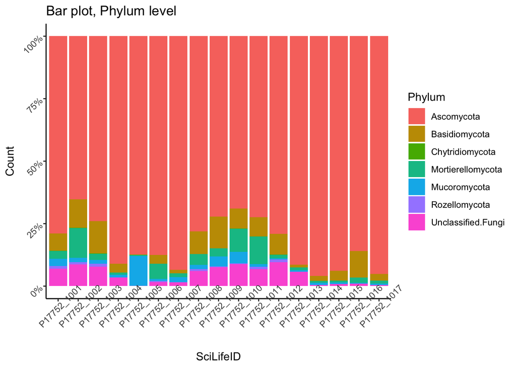

```r
colnames(taxa)[1] <- "OTU"

count_melt <- melt(counts_rar, varnames = c("OTU", "SciLifeID"), value.name = "Count")
count_melt <- count_melt[count_melt$Count>0,]
count_melt <- merge.data.frame(count_melt, meta, by = "SciLifeID")
count_melt <- merge.data.frame(count_melt, taxa, by = "OTU")
count_melt$SampleID <- factor(count_melt$SampleID, levels = c("MQ1", "MQ2","MQ4", "LMQ1", "LMQ2", "LMQ3", "LMQ4", "LMQ5", "S1", "S3", "S4", "S5", "LS1", "LS2", "LS3", "LS4", "LS5"))

(pp <- ggplot(count_melt, aes(x = SciLifeID, y = Count, fill = Phylum))+
  geom_bar(stat = "identity", position = "fill")+
  scale_y_continuous(labels = scales::percent)+
    ggtitle("Bar plot, Phylum level")+
    theme_classic()+
  #scale_fill_manual(values = sample(hue_pal()(length(unique(count_melt$Family)))))+
  theme(axis.text = element_text(angle = 45)))
```

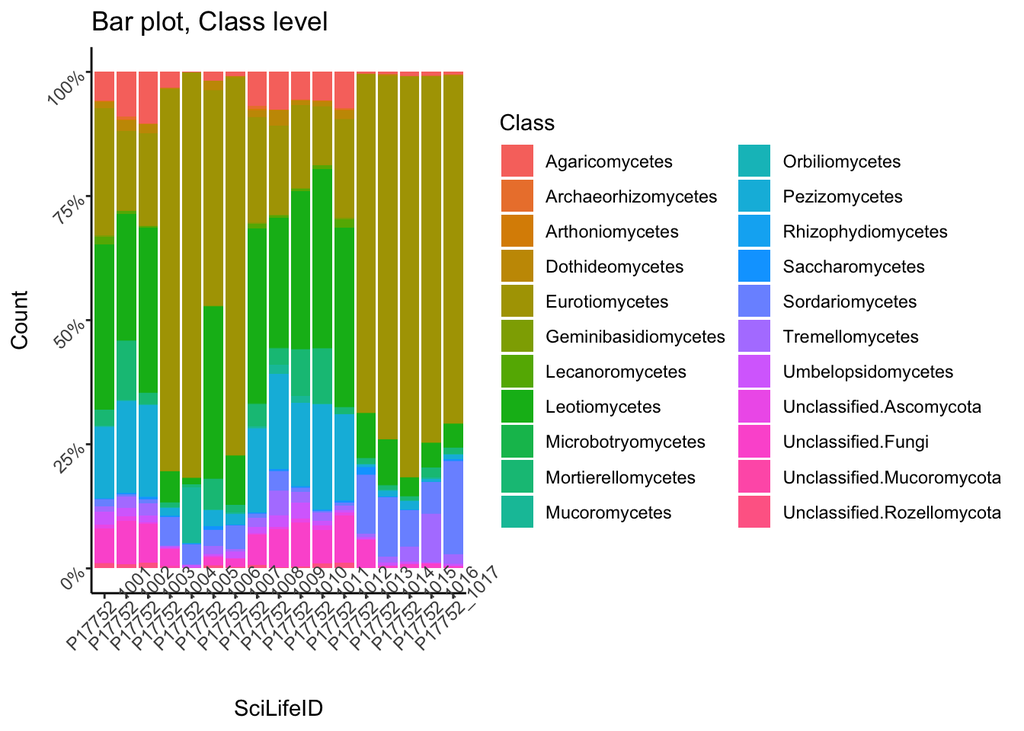

```r
# g_legend <- function(a.gplot){
#     tmp <- ggplot_gtable(ggplot_build(a.gplot))
#     leg <- which(sapply(tmp$grobs, function(x) x$name) == "guide-box")
#     legend <- tmp$grobs[[leg]]
#     legend
# }
#
# pp_legend <- g_legend(pp)

(pc <- ggplot(count_melt, aes(x = SciLifeID, y = Count, fill = Class))+
  geom_bar(stat = "identity", position = "fill")+
  scale_y_continuous(labels = scales::percent)+
    ggtitle("Bar plot, Class level")+
  #scale_fill_manual(values = sample(hue_pal()(length(unique(count_melt$Family)))))+
    theme_classic()+
  theme(axis.text = element_text(angle = 45)))
```

```r
# pc_legend <- g_legend(pc)
```

```r
# pdf(here("results/figures/FigureS3_legend.pdf"),
#     width = 6,
#     height = 8)
# grid.newpage()
# grid.draw(pp_legend)
# dev.off()
#
#
#
# pdf(here("results/figures/Figure5_legend.pdf"),
#     width = 10,
#     height = 8)
# grid.newpage()
# grid.draw(pc_legend)
# dev.off()
```

```r
#  ggsave("Figure5.pdf",
#    pc + theme(legend.position = "none"),
#        device = "pdf",
#        path = "results/figures",
#        width = 190,
#        height = 110,
#        units = "mm")
#
# ggsave("FigureS3.pdf",
#    pp + theme(legend.position = "none"),
#        device = "pdf",
#        path = "results/figures",
#        width = 190,
#        height = 110,
#        units = "mm")
```

It looks like there are consistent changes between the treatments, e.g. higher relative abundance of Ascomycota in the Sucrose samples.

From this and the PCoA it looks one of the sucrose samples (S4) is an outlier, so I will remove this sample before further analyses

```r
meta_rel2 <- meta_rel[-6,]
counts_rar2 <- counts_rar[,-6]
counts_rar2 <- counts_rar2[rowSums(counts_rar2)>0,]
```

## Test Class and Phylum abundance for statistical significance

To test statistically which classes and phyla are statistically different between the treatments, we can start with summarizing counts to Phylum and Class level.

```r
count_melt2 <- melt(counts_rar2, varnames = c("OTU", "SciLifeID"), value.name = "Count")
count_melt2 <- count_melt2[count_melt2$Count>0,]
count_melt2 <- merge.data.frame(count_melt2, meta_rel2, by = "SciLifeID")
count_melt2 <- merge.data.frame(count_melt2, taxa, by = "OTU")
class_mat <- acast(count_melt2, Class~SciLifeID, value.var = "Count", fun.aggregate = sum)
phylum_mat <- acast(count_melt2, Phylum~SciLifeID, value.var = "Count", fun.aggregate = sum)
#Remove "Unclassified Fungi"
class_mat <- class_mat[!grepl("Unclassified", rownames(class_mat)),]
phylum_mat <- phylum_mat[!grepl("Unclassified", rownames(phylum_mat)),]
```

Here using Linear discriminant analysis of effect size (lefse) to test for statistical significance of relative abundance of Classes and Phyla. It comes with a straight-forward visualization:

```r
set.seed(600)
meta_rel2$perfusate <- as.factor(meta_rel2$perfusate)

sumobj_class <- SummarizedExperiment(assays <- list(as.matrix(class_mat)),
                               colData = meta_rel2)

res_lefs_c <- lefser(sumobj_class, groupCol = "perfusate")
```

```
## The outcome variable is specified as 'perfusate' and the reference category is 'MQ'.
##  See `?factor` or `?relevel` to change the reference category.
```

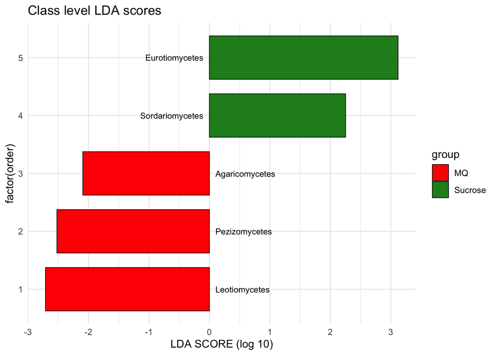

```r
lefserPlot(res_lefs_c)+
  theme_minimal()+
  ggtitle("Class level LDA scores")
```

```r
sumobj_phyl <- SummarizedExperiment(assays <- list(as.matrix(phylum_mat)),
                                     colData = meta_rel2)

res_lefs_p <- lefser(sumobj_phyl, groupCol = "perfusate")
```

```
## The outcome variable is specified as 'perfusate' and the reference category is 'MQ'.
##  See `?factor` or `?relevel` to change the reference category.
```

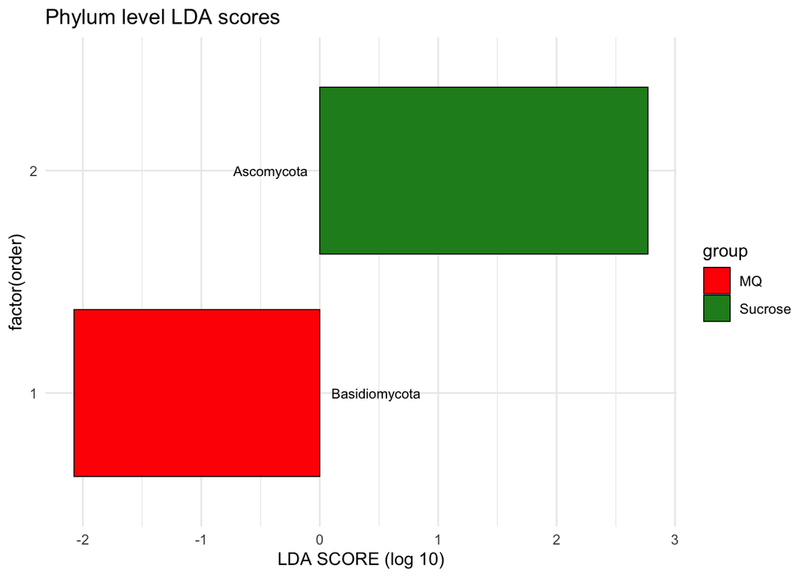

```r
lefserPlot(res_lefs_p)+
  theme_minimal()+
  ggtitle("Phylum level LDA scores")
```

```r
#Tables with average relative abundances of differentially abundant Phyla and classes:
class_mat_p <- prop.table(class_mat, margin = 2)*100
class_mat_p_r <- class_mat_p[res_lefs_c$Names[res_lefs_c$Names!="`NA`"],]
class_mat_p_r_m <- merge.data.frame(melt(class_mat_p_r, varnames = c("Class", "SciLifeID")), meta_rel2, by = "SciLifeID")
class_mat_p_r_m2 <- aggregate(class_mat_p_r_m$value, list(paste(class_mat_p_r_m$Class, class_mat_p_r_m$perfusate, sep = "_")), mean)
class_mat_p_r_m2[,3:4] <- str_split_fixed(class_mat_p_r_m2$Group.1, "_", 2)
class_mat_p_r_m2 <- class_mat_p_r_m2 %>% select(2:4) %>% relocate(V3, V4)
colnames(class_mat_p_r_m2) <- c("Class", "Perfusate", "Mean_Abund")
class_mat_p_r_m3 <- aggregate(class_mat_p_r_m$value, list(paste(class_mat_p_r_m$Class, class_mat_p_r_m$perfusate, sep = "_")), sd)
class_mat_p_r_m3[,3:4] <- str_split_fixed(class_mat_p_r_m3$Group.1, "_", 2)
colnames(class_mat_p_r_m3)[2:4] <- c("SD", "Class", "Perfusate")
class_mat_p_r_m2 <- cbind(class_mat_p_r_m2, class_mat_p_r_m3$SD)
class_mat_p_r_m2
```

```
##              Class Perfusate Mean_Abund class_mat_p_r_m3$SD
## 1   Agaricomycetes        MQ   8.009985           1.9241262
## 2   Agaricomycetes   Sucrose   0.944443           1.0158741
## 3   Eurotiomycetes        MQ  20.355494           4.4024112
## 4   Eurotiomycetes   Sucrose  76.455282           4.3615917
## 5    Leotiomycetes        MQ  35.501026           4.5985532
## 6    Leotiomycetes   Sucrose   6.266982           3.1244314
## 7    Pezizomycetes        MQ  19.679165           2.2126783
## 8    Pezizomycetes   Sucrose   1.136288           0.7167027
## 9  Sordariomycetes        MQ   1.270602           1.2700692
## 10 Sordariomycetes   Sucrose   9.003524           5.0591985
```

```r
phylum_mat_p <- prop.table(phylum_mat, margin = 2)*100
phylum_mat_p_r <- phylum_mat_p[res_lefs_p$Names[res_lefs_p$Names!="`NA`"],]
phylum_mat_p_r_m <- merge.data.frame(melt(phylum_mat_p_r, varnames = c("Class", "SciLifeID")), meta_rel2, by = "SciLifeID")
phylum_mat_p_r_m2 <- aggregate(phylum_mat_p_r_m$value, list(paste(phylum_mat_p_r_m$Class, phylum_mat_p_r_m$perfusate, sep = "_")), mean)
phylum_mat_p_r_m2[,3:4] <- str_split_fixed(phylum_mat_p_r_m2$Group.1, "_", 2)
phylum_mat_p_r_m2 <- phylum_mat_p_r_m2 %>% select(2:4) %>% relocate(V3, V4)
colnames(phylum_mat_p_r_m2) <- c("Phylum", "Perfusate", "Mean_Abund")
phylum_mat_p_r_m3 <- aggregate(phylum_mat_p_r_m$value, list(paste(phylum_mat_p_r_m$Class, phylum_mat_p_r_m$perfusate, sep = "_")), sd)
phylum_mat_p_r_m3[,3:4] <- str_split_fixed(phylum_mat_p_r_m3$Group.1, "_", 2)
colnames(phylum_mat_p_r_m3)[2:4] <- c("SD", "Class", "Perfusate")
phylum_mat_p_r_m2 <- cbind(phylum_mat_p_r_m2, phylum_mat_p_r_m3$SD)
phylum_mat_p_r_m2
```

```
##          Phylum Perfusate Mean_Abund phylum_mat_p_r_m3$SD
## 1    Ascomycota        MQ  79.779725             5.207055
## 2    Ascomycota   Sucrose  93.356252             3.983135
## 3 Basidiomycota        MQ  10.461721             2.573611
## 4 Basidiomycota   Sucrose   3.217008             3.280767
```

MQ: group 0 Sucrose: group 1

The bars showing up in the plots are significant (p<0.05). So Pezizomycetes, Leotiomycetes, Agaricomycetes are more abundant in MQ, while Eurotiomycetes and Sordariomycetes are higher abundant in the sucrose treatment. The Basidiomycota class Tremellomycetes (showing no significant changes) seems to consist of mostly parasites (with reported parasitism on fungi, plants and animals) that also have more harmless yeast-like stages, that have been described as “ubiquitous elemenents of aquatic and terrestrial ecosystems (McLaughlin et al., 2014).

On Phylum level the only significant changes are that there are more Ascomycotain the sucrose samples, and more Basidiomycota in the MQ samples.

## Clustered heatmap of normalized values

We normalize our count matrix using the zero inflation negative binomial method and plot the normalized values as a clustered heatmap.

```r
## Create summarised experiment object
sumobj <- SummarizedExperiment(assays <- list(as.matrix(counts_rar2)),
                               colData = meta_rel2)

sumobj_zinb <- zinbwave(sumobj, K = 2, epsilon = nrow(counts_rar2), normalizedValues = TRUE, residuals = TRUE)
```

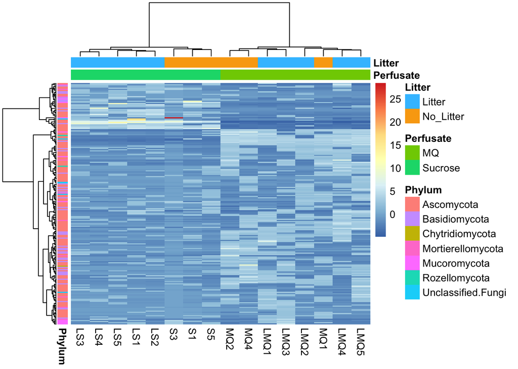

```r
#W <- reducedDim(sumobj_zinb)

counts_rar_norm <- assay(sumobj_zinb, "normalizedValues")

sample_cols <- data.frame(Perfusate=meta_rel2$perfusate,Litter=meta_rel2$Litter, row.names = meta_rel2$SciLifeID)

sample_rows <- data.frame(Phylum=taxa$Phylum[match(rownames(counts_rar_norm), taxa$OTU)], row.names = taxa$OTU[match(rownames(counts_rar_norm), taxa$OTU)])

pheatmap(counts_rar_norm,
         show_rownames = FALSE,
         labels_col = meta_rel2$SampleID,
         #scale = "row",
         clustering_distance_cols = "correlation",
         annotation_col = sample_cols,
         annotation_row = sample_rows,
         clustering_method = "ward.D")
```

```r
#Repeat with k=0 and epsilon=1e12 for DESeq
sumobj_zinb2 <- zinbwave(sumobj, K = 0, epsilon = 1e12, residuals = TRUE, observationalWeights = TRUE)
```

```r
#Print
pheatmap(counts_rar_norm,
         show_rownames = FALSE,
         labels_col = meta_rel2$SampleID,
         #scale = "row",
         clustering_distance_cols = "correlation",
         annotation_col = sample_cols,
         annotation_row = sample_rows,
         clustering_method = "ward.D",
         filename = here("results/figures/FigureS4.pdf"))
```

This again clearly shows the difference between the MQ and sucrose samples, with a number of fungi that are clearly much enriched in the sucrose samples (at the higher end of the heatmap). Interestingly, the litter seems to have a higher influence on what colonizes the sucrose probes.

## Differential abundance

```r
dds <- DESeqDataSet(sumobj_zinb2, design = ~ perfusate)
```

```
## renaming the first element in assays to 'counts'
```

```r
dds <- DESeq(dds, sfType = "poscounts", useT = TRUE, minmu = 1e-6)
```

```
## -- replacing outliers and refitting for 7 genes
## -- DESeq argument 'minReplicatesForReplace' = 7
## -- original counts are preserved in counts(dds)
```

```r
res <- results(dds, contrast = c("perfusate", "Sucrose", "MQ"))

res2 <- filterDE(res)
```

```
## [1] "Filtering by: padj = 0.01 and lfc= 0.5"
```

```r
dim(res2)
```

```
## [1] 24  6
```

```r
sum(res2$log2FoldChange>0)
```

```
## [1] 15
```

15 out of 24 significantly differentially abundant OTUs are more abundant in Sucrose! (This now also fits better with the visual impression from the heatmap)

These are the taxonomic annotations of the DA OTUs:

```r
da_OTUs <- cbind(as.data.frame(res2)[,c(1,2,6)],taxa[rownames(res2),-c(1:3)])
da_OTUs
```

```
##           baseMean log2FoldChange         padj Kingdom            Phylum
## SOTU1  3089.335488       5.335537 1.353058e-08   Fungi        Ascomycota
## SOTU10   63.719002       3.818905 3.015669e-06   Fungi        Ascomycota
## SOTU3   322.491916       5.826663 7.681231e-06   Fungi        Ascomycota
## SOTU17   30.328993       4.959144 1.285975e-05   Fungi        Ascomycota
## SOTU23   23.374331      -2.671472 2.473642e-04   Fungi        Ascomycota
## SOTU7    54.745359      -2.019049 7.428381e-04   Fungi        Ascomycota
## SOTU4   234.481327      -2.128451 1.669780e-03   Fungi        Ascomycota
## SOTU27   40.376566       5.713752 1.902754e-03   Fungi     Basidiomycota
## SOTU12   59.877407      -1.905327 1.982696e-03   Fungi     Basidiomycota
## SOTU29   16.521650      -2.011907 2.466854e-03   Fungi        Ascomycota
## SOTU33   11.803617      -2.926597 2.466854e-03   Fungi        Ascomycota
## SOTU37   10.565237       3.168592 2.466854e-03   Fungi        Ascomycota
## SOTU85    2.891935       4.377764 2.466854e-03   Fungi        Ascomycota
## SOTU32   14.621797       3.969606 3.379858e-03   Fungi        Ascomycota
## SOTU42    9.433247       4.293511 3.379858e-03   Fungi        Ascomycota
## SOTU56    4.678528       3.124608 3.379858e-03   Fungi        Ascomycota
## SOTU26   15.164988       1.520086 3.753494e-03   Fungi Mortierellomycota
## SOTU30   19.729827      -1.942490 3.753494e-03   Fungi        Ascomycota
## SOTU6     6.491691       2.078695 3.844538e-03   Fungi      Mucoromycota
## SOTU21   21.439257       3.126062 5.016752e-03   Fungi        Ascomycota
## SOTU11  119.003376       1.344665 5.269757e-03   Fungi        Ascomycota
## SOTU40    9.994716      -2.444469 5.592276e-03   Fungi     Rozellomycota
## SOTU58    4.714710       4.026861 8.554574e-03   Fungi      Mucoromycota
## SOTU13   52.454097      -1.301217 9.159512e-03   Fungi        Ascomycota
##                             Class                      Order
## SOTU1              Eurotiomycetes                 Eurotiales
## SOTU10             Eurotiomycetes                 Eurotiales
## SOTU3             Sordariomycetes                Hypocreales
## SOTU17              Leotiomycetes                 Helotiales
## SOTU23              Leotiomycetes                 Helotiales
## SOTU7               Leotiomycetes                 Helotiales
## SOTU4               Pezizomycetes                  Pezizales
## SOTU27            Tremellomycetes             Filobasidiales
## SOTU12             Agaricomycetes                 Atheliales
## SOTU29              Leotiomycetes                 Helotiales
## SOTU33              Leotiomycetes                 Helotiales
## SOTU37            Sordariomycetes          Chaetosphaeriales
## SOTU85            Sordariomycetes                Hypocreales
## SOTU32            Sordariomycetes                Hypocreales
```

[output cut: 45 more lines]

```
## SOTU29       Unclassified.Oidiodendron
## SOTU33         Unclassified.Helotiales
## SOTU37 Unclassified.Chaetosphaeriaceae
## SOTU85            Tolypocladium_album
## SOTU32           Unclassified.Pochonia
## SOTU42        Unclassified.Penicillium
## SOTU56         Lecanicillium_flavidum
## SOTU26        Mortierella_macrocystis
## SOTU30       Unclassified.Oidiodendron
## SOTU6                Mucor_silvaticus
## SOTU21        Unclassified.Trichoderma
## SOTU11        Unclassified.Penicillium
## SOTU40      Unclassified.Rozellomycota
## SOTU58       Unclassified.Mucoromycota
## SOTU13       Unclassified.Oidiodendron
```

```r
#write.csv(da_OTUs, here("results/analysis/da_OTUs.csv"), row.names = TRUE, quote = FALSE)
```

Next I want to plot the relative abundances of these differentially abundant OTUs.

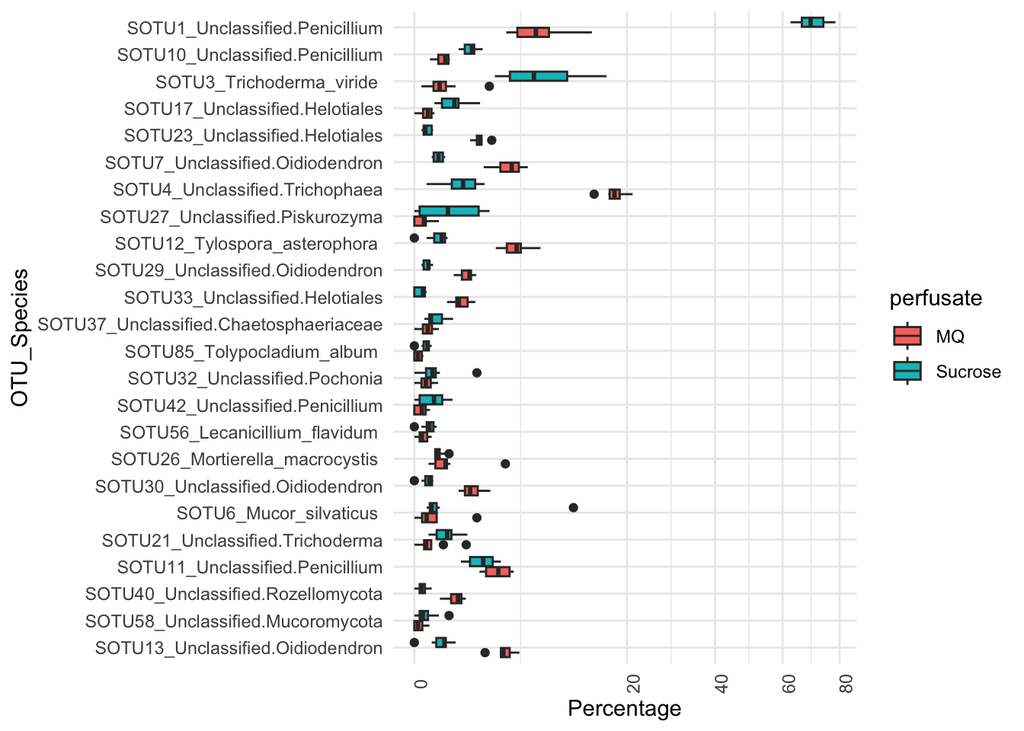

```r
counts_rar_p <- prop.table(counts_rar2, margin = 2)*100

counts_rar_p_da <- counts_rar_p[rownames(da_OTUs),]
da_perc <- reshape2::melt(counts_rar_p_da,
                varnames = c("OTU", "SciLifeID"),
                value.name = "Percentage")

da_perc <- merge.data.frame(da_perc, meta_rel2, by = "SciLifeID")
da_perc$OTU_Species <- paste0(da_perc$OTU, "_", da_OTUs$Species)
da_perc$OTU_Species <- factor(da_perc$OTU_Species, levels = rev(unique(da_perc$OTU_Species)))

ggplot(da_perc, aes(x = OTU_Species, y = Percentage, fill = perfusate))+
  geom_boxplot()+
  theme_minimal()+
  theme(axis.text.x = element_text(angle = 90))+
  coord_flip()+
  scale_y_continuous(trans='sqrt')
```

## Differential abundance between litter and non-litter sucrose samples

```r
seqtab.sw5_su_r2 <- seqtab.sw5_su_r[,-3]
seqtab.sw5_su_r2 <- seqtab.sw5_su_r2[rowSums(seqtab.sw5_su_r2)>0,]

sumobj_su <- SummarizedExperiment(assays <- list(as.matrix(seqtab.sw5_su_r2)),
                               colData = meta_rel2[meta_rel2$perfusate=="Sucrose",])


sumobj_zinb_su <- zinbwave(sumobj_su, K = 0, epsilon = 1e12, normalizedValues = TRUE, residuals = TRUE, observationalWeights = TRUE)
dds_su <- DESeqDataSet(sumobj_zinb_su, design = ~ Litter)
```

```
## renaming the first element in assays to 'counts'
```

```r
dds_su <- DESeq(dds_su, sfType = "poscounts", useT = TRUE, minmu = 1e-6)
res_su <- lfcShrink(dds_su, contrast = c("Litter", "Litter", "No_Litter"), type = "normal")
```

```
## using 'normal' for LFC shrinkage, the Normal prior from Love et al (2014).
##
## Note that type='apeglm' and type='ashr' have shown to have less bias than type='normal'.
## See ?lfcShrink for more details on shrinkage type, and the DESeq2 vignette.
## Reference: https://doi.org/10.1093/bioinformatics/bty895
```

```r
res_su2 <- filterDE(res_su)
```

```
## [1] "Filtering by: padj = 0.01 and lfc= 0.5"
```

```r
dim(res_su2)
```

```
## [1] 0 6
```

```r
sum(res_su2$log2FoldChange>0)
```

```
## [1] 0
```

DESeq2 does not find any signficantly differentially abundant OTUs between litter and no litter for the sucrose treatment.